# Applying RCTDE to Spatial Transcriptomics Data: Cell-to-cell interactions

Dylan Cable

December 19th, 2021

```r
library(spacexr)
library(Matrix)
library(doParallel)
```

```r
library(ggplot2)
datadir <- system.file("extdata",'SpatialRNA/Vignette',package = 'spacexr') # directory for sample Slide-seq dataset
if(!dir.exists(datadir))
  dir.create(datadir)
savedir <- 'RCTD_results'
if(!dir.exists(savedir))
  dir.create(savedir)
```

## Introduction

Robust Cell Type Differential Expression, or RCTDE, is part of the spacexr R package for learning cell type-specific differential expression from spatial transcriptomics data. In this Vignette, we will use RCTDE to test for cell-to-cell interactions in a toy cerebellum Slide-seq dataset. First, we will first use RCTD to assign cell types to a cerebellum Slide-seq dataset. We will define cell type profiles using an annotated single nucleus RNA-sequencing (snRNA-seq) cerebellum dataset. We will test for differential expression as a function of colocalization with a particular cell type.

## Data Preprocessing and running RCTD

First, we run RCTD on the data to annotated cell types. Please note that this follows exactly the content of the spatial transcriptomics RCTD vignette (doublet mode). Please refer to the [spatial transcriptomics vignette](https://raw.githack.com/dmcable/spacexr/master/vignettes/spatial-transcriptomics.html) for more explanation on the RCTD algorithm.

```r
### Load in/preprocess your data, this might vary based on your file type
if(!file.exists(file.path(savedir,'myRCTD.rds'))) {
  counts <- read.csv(file.path(datadir,"MappedDGEForR.csv")) # load in counts matrix
  coords <- read.csv(file.path(datadir,"BeadLocationsForR.csv"))
  rownames(counts) <- counts[,1]; counts[,1] <- NULL # Move first column to rownames
  rownames(coords) <- coords$barcodes; coords$barcodes <- NULL # Move barcodes to rownames
  nUMI <- colSums(counts) # In this case, total counts per pixel is nUMI
  puck <- SpatialRNA(coords, counts, nUMI)
  barcodes <- colnames(puck@counts) # pixels to be used (a list of barcode names).
  plot_puck_continuous(puck, barcodes, puck@nUMI, ylimit = c(0,round(quantile(puck@nUMI,0.9))),
                       title ='plot of nUMI')
  refdir <- system.file("extdata",'Reference/Vignette',package = 'spacexr') # directory for the reference
  counts <- read.csv(file.path(refdir,"dge.csv")) # load in counts matrix
  rownames(counts) <- counts[,1]; counts[,1] <- NULL # Move first column to rownames
  meta_data <- read.csv(file.path(refdir,"meta_data.csv")) # load in meta_data (barcodes, clusters, and nUMI)
  cell_types <- meta_data$cluster; names(cell_types) <- meta_data$barcode # create cell_types named list
  cell_types <- as.factor(cell_types) # convert to factor data type
  nUMI <- meta_data$nUMI; names(nUMI) <- meta_data$barcode # create nUMI named list
  reference <- Reference(counts, cell_types, nUMI)
  myRCTD <- create.RCTD(puck, reference, max_cores = 2)
  myRCTD <- run.RCTD(myRCTD, doublet_mode = 'doublet')
  saveRDS(myRCTD,file.path(savedir,'myRCTD.rds'))
}
```

## Create explanatory variable / covariate

Now that we have successfully run RCTD, we can create a explanatory variable (i.e. covariate) used for predicting differential expression in RCTDE. In general one should set the explanatory variable to biologically relevant predictors of gene expression such as spatial position.

The explanatory variable itself is a vector of values, constrained between 0 and 1, with names matching the pixel names of the `myRCTD` object. In this case, we will use the explanatory variable as the density of cell type ‘6’. We will calculate this explanatory variable using the `exvar.celltocell.interactions`, which calculates cell type density using an exponential filter.

Here, we also artifically upregulate the expression of the Malat1 gene (in regions of high explanatory variable) to see whether RCTDE can detect this differentially expressed gene.

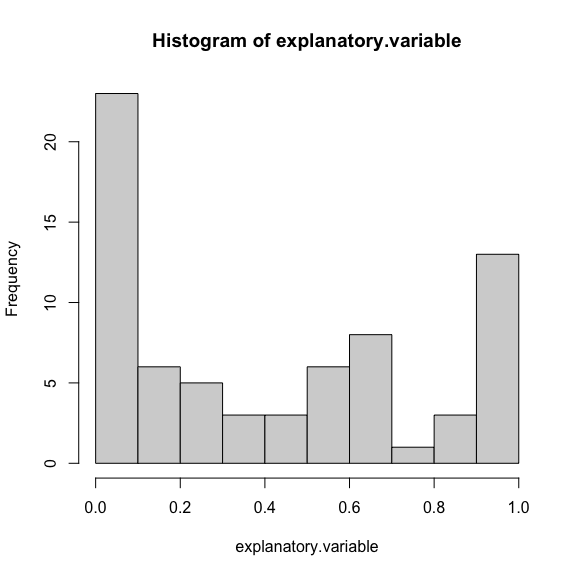

```r
### Create SpatialRNA object
myRCTD <- readRDS(file.path(savedir,'myRCTD.rds'))
barcodes <- colnames(myRCTD@spatialRNA@counts)
cell_type_interacting <- '6'
explanatory.variable <- exvar.celltocell.interactions(myRCTD, barcodes, cell_type_interacting, radius = 500)
print(head(explanatory.variable))
hist(explanatory.variable)
```

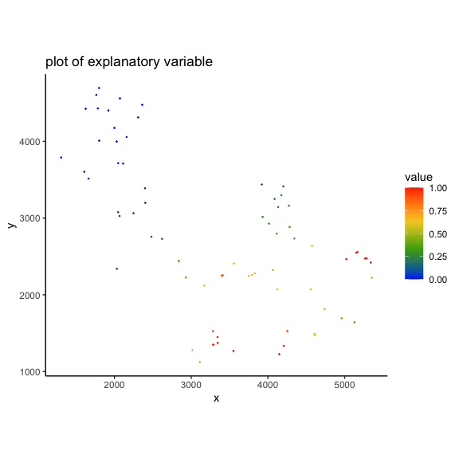

```r
# Differentially upregulate one gene
change_gene <- 'Malat1'
high_barc <- names(explanatory.variable[explanatory.variable > 0.5])
low_barc <- names(explanatory.variable[explanatory.variable < 0.5])
myRCTD@originalSpatialRNA@counts[change_gene, high_barc] <- myRCTD@spatialRNA@counts[change_gene, high_barc] * 2

plot_puck_continuous(myRCTD@spatialRNA, names(explanatory.variable), explanatory.variable, ylimit = c(0,1), title ='plot of explanatory variable')
```

## Running RCTDE

After creating the explanatory variable, we are now ready to run RCTDE using the `run.RCTDE.single` function. We will use two cores, and a false discovery rate of 0.25. Next, we will set a gene threshold (i.e. minimum gene expression) of 0.01, and we will set a cell_type_threshold (minimum instances per cell type) of 10.

**Warning**: On this toy dataset, we have made several choices of parameters that are not recommended for regular use. On real datasets, we recommend first consulting the RCTDE default parameters. This includes `gene_threshold` (default 5e-5), `cell_type_threshold` (default 125), and `fdr` (default 0.01). Please see `?run.RCTDE.single` for more information on these parameters.

```r
#de
myRCTD@config$max_cores <- 2
myRCTD <- run.RCTDE.single(myRCTD, explanatory.variable, gene_threshold = .01,
                         cell_type_threshold = 10, fdr = 0.25)
```

```
#> choose_cell_types: running de with cell types 10, 18
#> run.RCTDE.general: configure params_to_test = 2
```

```r
saveRDS(myRCTD,file.path(savedir,'myRCTDde_celltocell.rds'))
```

Equivalently to using the `run.RCTDE.single` function, those who want to have more precise control can build the design matrix directly. In this case, we use the `build.designmatrix.single` function, which constructs the design matrix for a single explanatory variable. After constucting the design matrix, one can use the `run.RCTDE` function to run RCTDE with this general design matrix.

```r
X <- build.designmatrix.single(myRCTD, explanatory.variable)
print(head(X))
```

```
#>                  explanatory.variable
#> TTGGACGTTTCAAT 1          0.884414796
#> CACGGCCATATTGC 1          0.579439575
#> CCCCCCCCATTGAA 1          1.000000000
#> CGCTTGGCATTTAC 1          0.617443581
#> CGTGAGTTTCTCCT 1          0.294774979
#> ATTCAGTCGCATTA 1          0.005677704
```

```r
barcodes <- names(explanatory.variable)
cell_types <- c('10', '18')
myRCTD_identical <- run.RCTDE(myRCTD, X, barcodes, cell_types, gene_threshold = .01,
                        cell_type_threshold = 10, fdr = 0.25)
```

```
#> choose_cell_types: running de with cell types 10, 18
#> run.RCTDE.general: configure params_to_test = 2
```

## RCTDE results

After running RCTDE, it is time to examine RCTDE results. RCTDE model fits for all genes are stored in `myRCTD@de_results$gene_fits`, and we demonstrate below how to access the point estimates, standard errors, and convergence. We will focus on cell type 10. Furthermore, we will examine the original Malat1 gene, which was differentially expressed in cell type 10.

```r
#print results for cell type '18'
cell_type <- '10'
sig_gene <- change_gene
print(paste("following results hold for", sig_gene))
```

```
#> [1] "following results hold for Malat1"
```

```r
print("check for covergence of each cell type")
```

```
#> [1] "check for covergence of each cell type"
```

```r
print(myRCTD@de_results$gene_fits$con_mat[sig_gene, ])
```

```
#>   10   18
#> TRUE TRUE
```

```r
print('estimated DE')
```

```
#> [1] "estimated DE"
```

```r
print(myRCTD@de_results$gene_fits$mean_val[sig_gene, ])
```

```
#>        10        18
#> 0.9745365 0.4198345
```

```r
print('standard errors for non-intercept terms')
```

```
#> [1] "standard errors for non-intercept terms"
```

```r
print(myRCTD@de_results$gene_fits$s_mat[sig_gene, c(2,4)])
```

```
#>    2_2_10    2_2_18
#> 0.2618954 0.5773736
```

Finally, we will plot RCTDE results in the `savedir` directory!

The following plot shows a spatial visualization of the Malat1 gene, which was determined to be differentially expressed.

The function `make_all_de_plots` will automatically generate several types of plots displaying the RCTDE results across all genes and cell types.

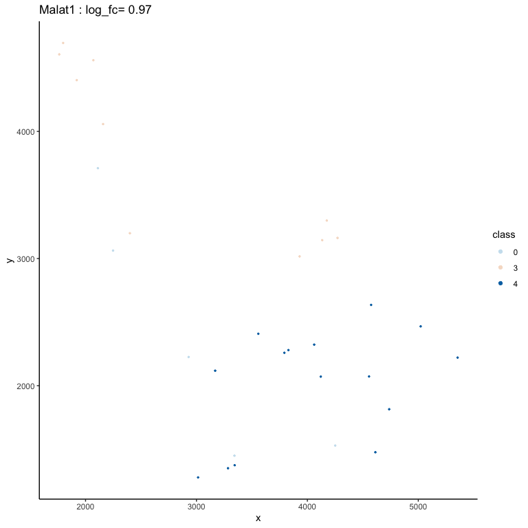

```r
myRCTD <- readRDS(file.path(savedir,'myRCTDde_celltocell.rds'))
plot_gene_two_regions(myRCTD, sig_gene, cell_type, min_UMI = 10, expr.thresh = 25)
```

```r
make_all_de_plots(myRCTD, savedir)
```